# 用pkgdown为R程序包建立网站

Jinlong Zhang

3/25/2021

- 为R程序包建立project
- 管理Rstudio中的git选项卡
- 用pkgdown编译网站
- 将docs文件夹上传到github
- 设定github展示网页
- 修改与重新发布

# 1 目的

本文以HK80程序包为例 (http://helixcn.github.io/HK80/)，介绍怎样将R 包的帮助文件（Rd文件）和vignettes中的Rmd文件等编译为网站并发布到github pages，以方便浏览。

# 2 所需软件

操作的主要在Rstudio中完成。

# 3 为R程序包建立project

在Rstudio中管理R包，一般要建立一个Rproject，以便于管理，因此先介绍如何创建R包的Rproject。

方法为：File>New Project>Existing Directory，找到程序包的源代码所在文件夹，打开即可。

建立R项目将对程序包内的R代码进行格式化（如调整换行和缩进），同时会创建.Rproj、.gitignore等文件。

[figure not shown]

图1. 建立新项目

[figure not shown]

图2. 基于已有文件夹建立新项目

.gitignore是一个纯文本文件，保存的是不想同步到github的文件列表。不同项目的.gitignore一般来说也是不同的。Rstudio创建的.gitignore文件对于一般的R包项目已经足够。

# 4 管理Rstudio中的git选项卡

[figure not shown]

图3. git选项卡与等待提交（commit）的文件

创建好Rproject之后，可以看到在Rstudio的addin中，也增加了若干选项卡：

[figure not shown]

图4. Rstudio的Addin选项

[figure not shown]

图5. 安装、检查和编译R程序包选项

- 在Build选项卡中，可找到安装程序包、编译程序包源代码的按钮。
- 在git选项卡中，可找到任何内容有更改的文件名，并有diff、commit、pull、push等按钮。代码做了修改以后有哪些变化，点击diff即可查看。若有文件做了改动，需要提交修改，则可以点击commit，同时提供相应的备注（message）。
- commit提交以后，本地的修改已经放入git缓存中，但是仍然未与github上的仓库同步，点击push即可提交到github网站。

不过，有时github上的网站可能通过网页版本编辑过，与本地版本不一致，此时，应该先点击pull，将本地文件夹中的源文件与github同步，再从最新版本开始修改，以免发生版本冲突。

# 5 用pkgdown生成网站

1. 在R中输入 `usethis::use_pkgdown()`，程序包的根目录将自动创建_pkgdown.yml，而且其他如.gitignore等会也被自动修改。

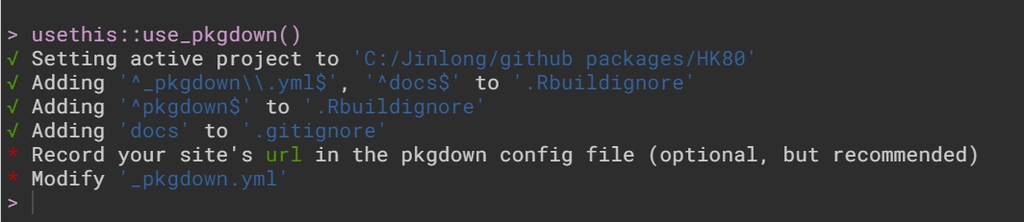

图6. 项目中整合pkgdown

Rstudio会自动打开pkgdown.yml等待用户编辑，不过一般情况下并不需要编辑。

要将文档编译为pkgdown网站，用如下命令：

```
pkgdown::build_site()
```

该命令将编译README.md文件，man文件夹下的rd文件以及vigenettes下的Rmd文件，并将read.md文件作为程序包网站的首页，编译好的各文件自动包含了knitr运行的结果（如各函数帮助文件的图表等）。编译完成，则程序包根目录下会生成docs文件夹，里面保存了用pkgdown生成的网站。

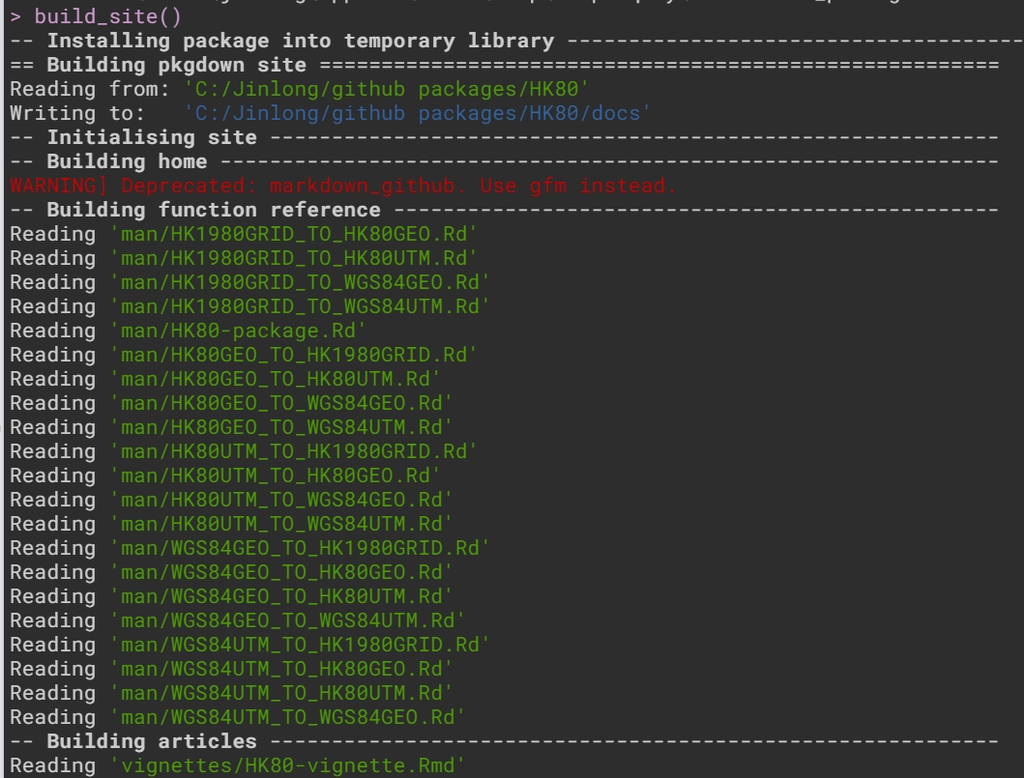

图7. pkg程序包正在编译文档，生成网站

# 6 将docs文件夹上传到github

虽然网站已经生成，但git不会自动将docs文件夹上传到github，这是因为该文件夹在.gitignore中默认是被忽略的。要将网站上传到github，需要先更改.gitignore。

修改的方法是：打开.gitignore文件，在doc前面加上一个英文井号，将这一行注释掉。

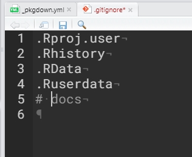

图8. 编辑.gitignore文件

回到Rstudio的git窗口，doc文件夹现在变成可见了。

[figure not shown]

图9. 待commit到git缓存中的文件

勾选docs文件夹，点击commit，写好相应的备注信息message，docs文件夹下所有的内容就放入了git的本地缓存中。

[figure not shown]

图10. 提交时为了更好记录更改历史，要提供message

按右上角的push按钮（向上的绿色箭头），即可将修改上传到github网站。

# 7 让docs下的网站可以从github访问

怎样才能让网址 (https://helixcn.github.io/HK80) 显示 docs文件夹中的内容呢？

方法如下：

打开 https://github.com/helixcn/hk80 网页，修改settings中的GitHub Pages选项。

路径为：Settings>GitHub Pages>Source>Master>/docs 点击 save（保存）。

保存后，网站 https://helixcn.github.io/HK80 即可浏览。

[figure not shown]

图11. HK80的源代码网页，注意右上角的Settings

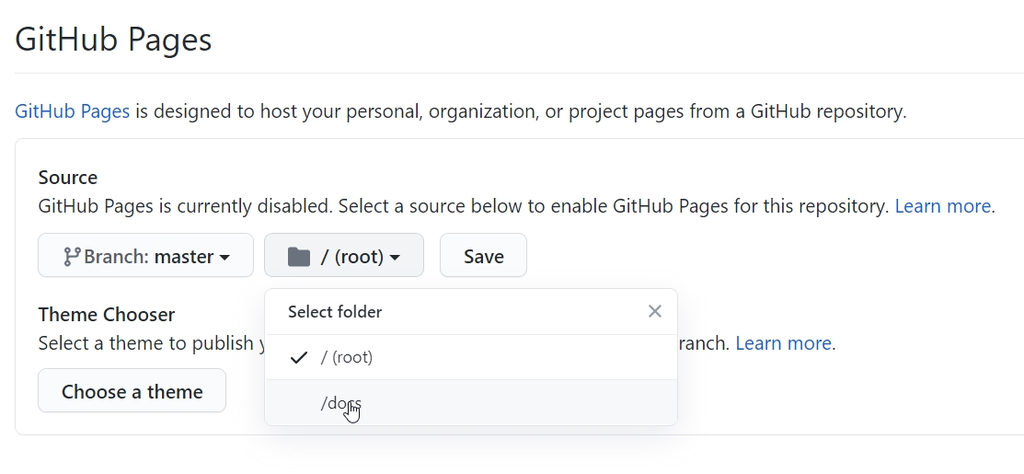

图12. GitHub pages的设定

# 8 修改与重新发布

若R的文档文件进行过任何修改，则需要重新运行`pkgdown::build_site()`以更新docs文件夹中的内容。每一次对程序包的代码修改以后，都需要在git面板提交(commit)，然后用push同步到github的仓库中。当然，输入git命令行的用户可以直接通过命令行提交。

# 进一步阅读

- R package down模板 https://pkgdown.r-lib.org/
- 为新手准备的现代化 R 包开发流程 https://cosx.org/2021/02/writing-r-packages-a-modern-workflow-for-beginners/